# Investigation of White Wine Quality Based on Chemical Properties by Tamunotonye Harry

> **Introduction**: This dataset is public available for research. The details are described in [Cortez et al., 2009].

P. Cortez, A. Cerdeira, F. Almeida, T. Matos and J. Reis. Modeling wine preferences by data mining from physicochemical properties. In Decision Support Systems, Elsevier, 47(4):547-553. ISSN: 0167-9236.

Available at: [@Elsevier] http://dx.doi.org/10.1016/j.dss.2009.05.016 [Pre-press (pdf)] http://www3.dsi.uminho.pt/pcortez/winequality09.pdf [bib] http://www3.dsi.uminho.pt/pcortez/dss09.bib

1. Title: Wine Quality
2. Sources Created by: Paulo Cortez (Univ. Minho), Antonio Cerdeira, Fernando Almeida, Telmo Matos and Jose Reis (CVRVV) @ 2009
3. Past Usage:

P. Cortez, A. Cerdeira, F. Almeida, T. Matos and J. Reis. Modeling wine preferences by data mining from physicochemical properties. In Decision Support Systems, Elsevier, 47(4):547-553. ISSN: 0167-9236.

In the above reference, two datasets were created, using red and white wine samples. The inputs include objective tests (e.g. PH values) and the output is based on sensory data (median of at least 3 evaluations made by wine experts). Each expert graded the wine quality between 0 (very bad) and 10 (very excellent). Several data mining methods were applied to model these datasets under a regression approach. The support vector machine model achieved the best results. Several metrics were computed: MAD, confusion matrix for a fixed error tolerance (T), etc. Also, we plot the relative importances of the input variables (as measured by a sensitivity analysis procedure).

4. Relevant Information:

The two datasets are related to red and white variants of the Portuguese “Vinho Verde” wine. For more details, consult: http://www.vinhoverde.pt/en/ or the reference [Cortez et al., 2009]. Due to privacy and logistic issues, only physicochemical (inputs) and sensory (the output) variables are available (e.g. there is no data about grape types, wine brand, wine selling price, etc.).

These datasets can be viewed as classification or regression tasks. The classes are ordered and not balanced (e.g. there are munch more normal wines than excellent or poor ones). Outlier detection algorithms could be used to detect the few excellent or poor wines. Also, we are not sure if all input variables are relevant. So it could be interesting to test feature selection methods.

5. Number of Instances: red wine - 1599; white wine - 4898.
6. Number of Attributes: 11 + output attribute

Note: several of the attributes may be correlated, thus it makes sense to apply some sort of feature selection.

7. Attribute information:

For more information, read [Cortez et al., 2009].

Input variables (based on physicochemical tests): 1 - fixed acidity (tartaric acid - g / dm^3) 2 - volatile acidity (acetic acid - g / dm^3) 3 - citric acid (g / dm^3) 4 - residual sugar (g / dm^3) 5 - chlorides (sodium chloride - g / dm^3 6 - free sulfur dioxide (mg / dm^3) 7 - total sulfur dioxide (mg / dm^3) 8 - density (g / cm^3) 9 - pH 10 - sulphates (potassium sulphate - g / dm3) 11 - alcohol (% by volume) Output variable (based on sensory data): 12 - quality (score between 0 and 10)

8. Missing Attribute Values: None
9. Description of attributes:

1 - fixed acidity: most acids involved with wine or fixed or nonvolatile (do not evaporate readily)

2 - volatile acidity: the amount of acetic acid in wine, which at too high of levels can lead to an unpleasant, vinegar taste

3 - citric acid: found in small quantities, citric acid can add ‘freshness’ and flavor to wines

4 - residual sugar: the amount of sugar remaining after fermentation stops, it’s rare to find wines with less than 1 gram/liter and wines with greater than 45 grams/liter are considered sweet

5 - chlorides: the amount of salt in the wine

6 - free sulfur dioxide: the free form of SO2 exists in equilibrium between molecular SO2 (as a dissolved gas) and bisulfite ion; it prevents microbial growth and the oxidation of wine

7 - total sulfur dioxide: amount of free and bound forms of S02; in low concentrations, SO2 is mostly undetectable in wine, but at free SO2 concentrations over 50 ppm, SO2 becomes evident in the nose and taste of wine

8 - density: the density of water is close to that of water depending on the percent alcohol and sugar content

9 - pH: describes how acidic or basic a wine is on a scale from 0 (very acidic) to 14 (very basic); most wines are between 3-4 on the pH scale

10 - sulphates: a wine additive which can contribute to sulfur dioxide gas (S02) levels, wich acts as an antimicrobial and antioxidant

11 - alcohol: the percent alcohol content of the wine

Output variable (based on sensory data): 12 - quality (score between 0 and 10)

# Univariate Plots Section

```
## [1] 4898   13
```

```
## 'data.frame':    4898 obs. of  13 variables:
##  $ fixed.acidity       : num  7 6.3 8.1 7.2 7.2 8.1 6.2 7 6.3 8.1 ...
##  $ volatile.acidity    : num  0.27 0.3 0.28 0.23 0.23 0.28 0.32 0.27 0.3 0.22 ...
##  $ citric.acid         : num  0.36 0.34 0.4 0.32 0.32 0.4 0.16 0.36 0.34 0.43 ...
##  $ residual.sugar      : num  20.7 1.6 6.9 8.5 8.5 6.9 7 20.7 1.6 1.5 ...
##  $ chlorides           : num  0.045 0.049 0.05 0.058 0.058 0.05 0.045 0.045 0.049 0.044 ...
##  $ free.sulfur.dioxide : num  45 14 30 47 47 30 30 45 14 28 ...
##  $ total.sulfur.dioxide: num  170 132 97 186 186 97 136 170 132 129 ...
##  $ density             : num  1.001 0.994 0.995 0.996 0.996 ...
##  $ pH                  : num  3 3.3 3.26 3.19 3.19 3.26 3.18 3 3.3 3.22 ...
##  $ sulphates           : num  0.45 0.49 0.44 0.4 0.4 0.44 0.47 0.45 0.49 0.45 ...
##  $ alcohol             : num  8.8 9.5 10.1 9.9 9.9 10.1 9.6 8.8 9.5 11 ...
##  $ quality             : int  6 6 6 6 6 6 6 6 6 6 ...
##  $ quality.factor      : Ord.factor w/ 7 levels "3"<"4"<"5"<"6"<..: 4 4 4 4 4 4 4 4 4 4 ...
```

```
##  fixed.acidity    volatile.acidity  citric.acid     residual.sugar
##  Min.   : 3.800   Min.   :0.0800   Min.   :0.0000   Min.   : 0.600
##  1st Qu.: 6.300   1st Qu.:0.2100   1st Qu.:0.2700   1st Qu.: 1.700
##  Median : 6.800   Median :0.2600   Median :0.3200   Median : 5.200
##  Mean   : 6.855   Mean   :0.2782   Mean   :0.3342   Mean   : 6.391
##  3rd Qu.: 7.300   3rd Qu.:0.3200   3rd Qu.:0.3900   3rd Qu.: 9.900
##  Max.   :14.200   Max.   :1.1000   Max.   :1.6600   Max.   :65.800
##
##    chlorides       free.sulfur.dioxide total.sulfur.dioxide
##  Min.   :0.00900   Min.   :  2.00      Min.   :  9.0
##  1st Qu.:0.03600   1st Qu.: 23.00      1st Qu.:108.0
##  Median :0.04300   Median : 34.00      Median :134.0
##  Mean   :0.04577   Mean   : 35.31      Mean   :138.4
##  3rd Qu.:0.05000   3rd Qu.: 46.00      3rd Qu.:167.0
##  Max.   :0.34600   Max.   :289.00      Max.   :440.0
##
##     density             pH          sulphates         alcohol
##  Min.   :0.9871   Min.   :2.720   Min.   :0.2200   Min.   : 8.00
##  1st Qu.:0.9917   1st Qu.:3.090   1st Qu.:0.4100   1st Qu.: 9.50
##  Median :0.9937   Median :3.180   Median :0.4700   Median :10.40
##  Mean   :0.9940   Mean   :3.188   Mean   :0.4898   Mean   :10.51
##  3rd Qu.:0.9961   3rd Qu.:3.280   3rd Qu.:0.5500   3rd Qu.:11.40
##  Max.   :1.0390   Max.   :3.820   Max.   :1.0800   Max.   :14.20
##
##     quality      quality.factor
##  Min.   :3.000   3:  20
##  1st Qu.:5.000   4: 163
##  Median :6.000   5:1457
##  Mean   :5.878   6:2198
##  3rd Qu.:6.000   7: 880
##  Max.   :9.000   8: 175
##                  9:   5
```

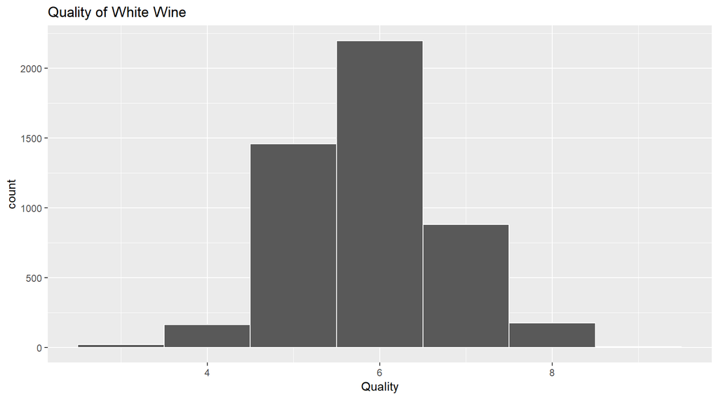

Since I the quality feature is the center of my analysis, I needed to know the total distribution of white wines relating to quantity. A majority of them seem to have 6 as their quality with very few at 9. This will aid me in further exploration of the data.

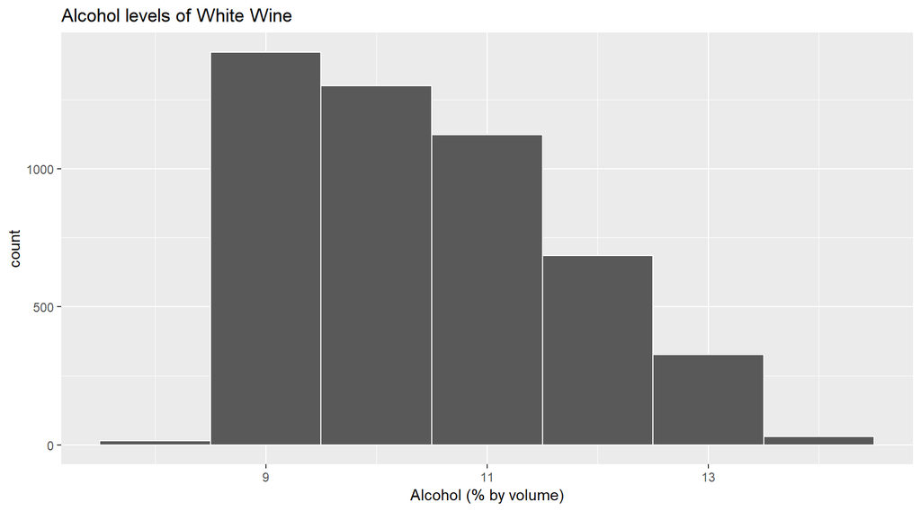

This plot made lots of sense to me because alcohol contributes to the flavour of wine. Glycerol (glycerine) has an effect on the viscosity and sweetness of wine. (http://www.wineskills.co.uk/winemaking/winemaking-knowledge-base/chemical-composition). I needed to know the level of alcohol (% by volume) for each observation.

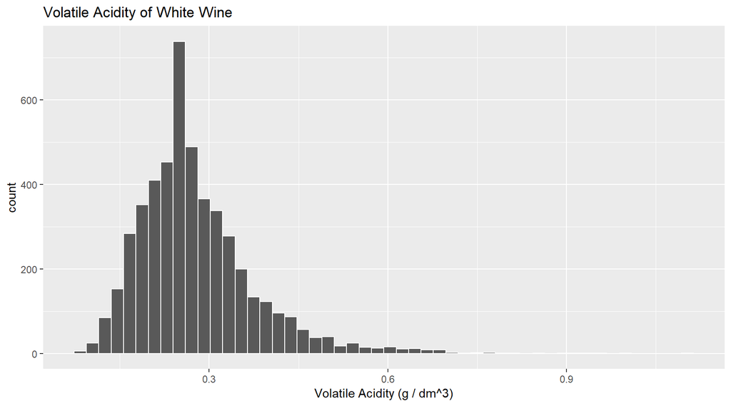

When thinking of wines before now, acidity always came to mind. They are responsible for the fresh crisp taste of wine according to wineskills.co.uk.

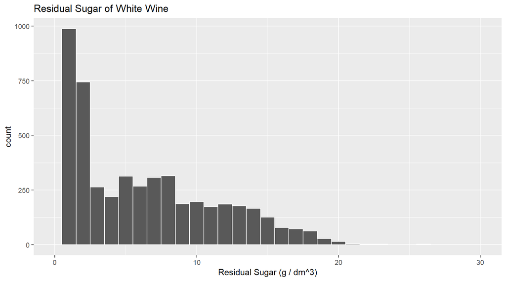

Instinctively the quantity of carbohydrates(sugar) stood out for me when I read about the constituents that determines a quality wine. I might be wrong because of how much(very low) I consume white wine.

This distribution is right-skewed with a majority of observations in the dataset being inbetween 0 - 10 g/dm^3.The highest count is inbetween 750 - 100 but closer to 1000.

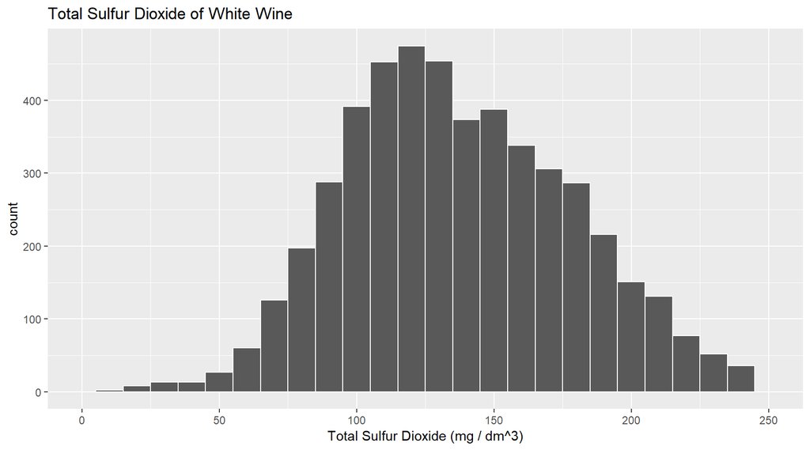

I was curious to know if sulfur had a significance in changing the quality of wine.

Examining the structure of this constituent, this plot shows a somewhat normal distribution with the highest counts being between 100 - 150 mg/dm^3

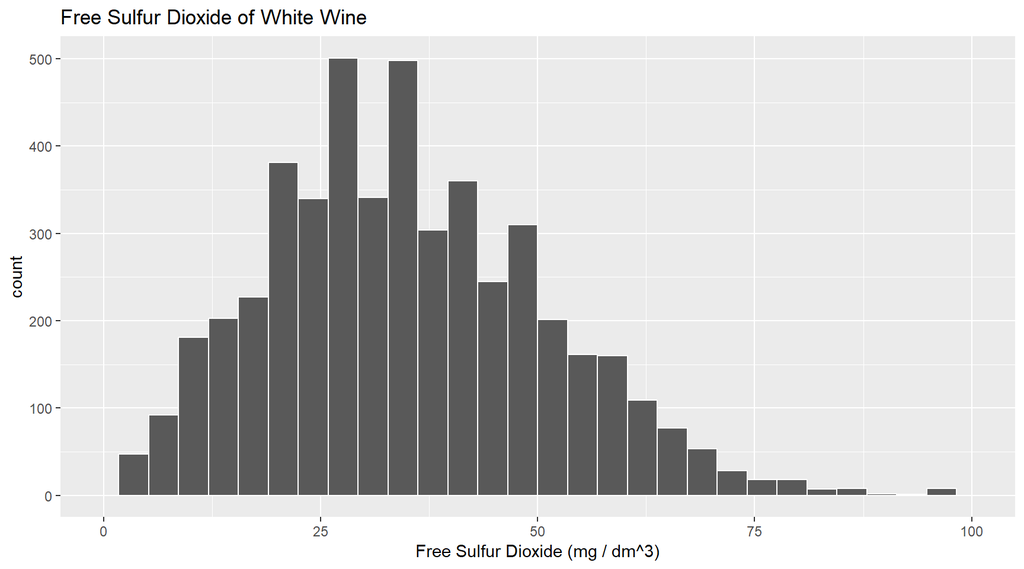

Same as the above description. In this case the highest counts were observed between 25 and 30 mg/dm^3 of Free Sulfur Dioxide

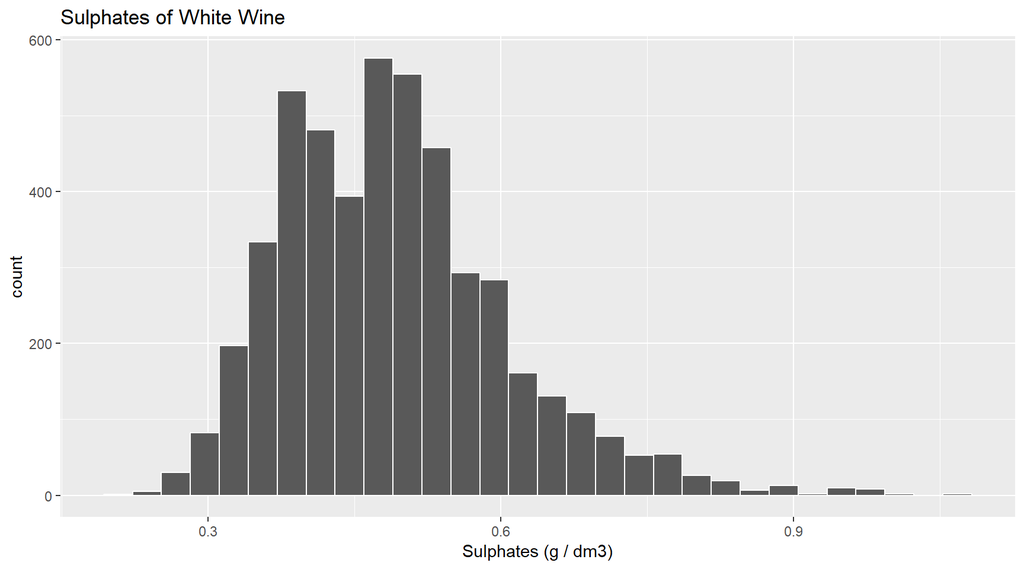

# Univariate Analysis

### What is the structure of your dataset?

Our dataset consists of 13 variables, with almost 4,898 observations.

### What is/are the main feature(s) of interest in your dataset?

Measure of the Quality of White Wine.

### What other features in the dataset do you think will help support your investigation into your feature(s) of interest?

- pH
- Alcohol
- Residual Sugar
- Free Sulfur Dioxide
- Density

### Did you create any new variables from existing variables in the dataset?

I created a new variable called “quality.factor” to help order the numbers given to represent quality and help me analyse the data given.

### Of the features you investigated, were there any unusual distributions? Did you perform any operations on the data to tidy, adjust, or change the form of the data? If so, why did you do this?

I noticed that the data was accompanied with a serial number in the column ‘X’ and I don’t need that for my investigation.

# Bivariate Plots Section

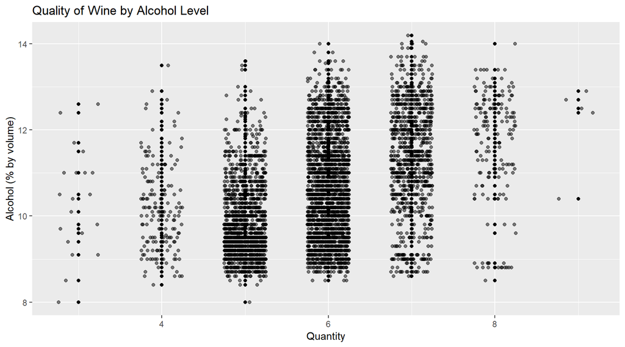

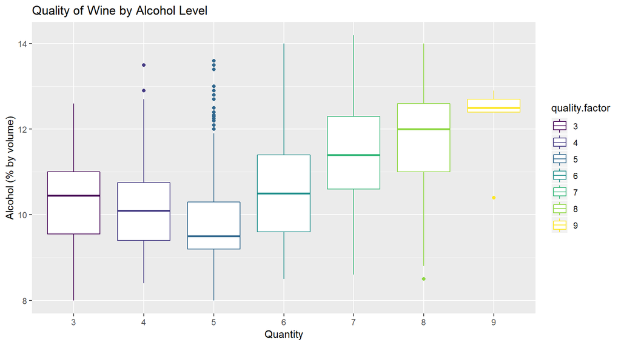

Pairing alcohol and quality of whine, I wanted to know if an increase in alcohol led to an increase in the quality of wine.

The above plots show that an increase in alcohol led to an increase in quality although it’s moderate. The boxplot shows the range of observations present.

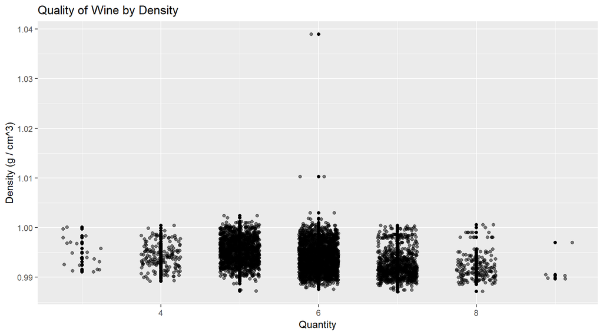

I was curious to know if increase in density resulted in an increase in quantity.

Not so surprised to see that there was a decrease in density as quality increase.

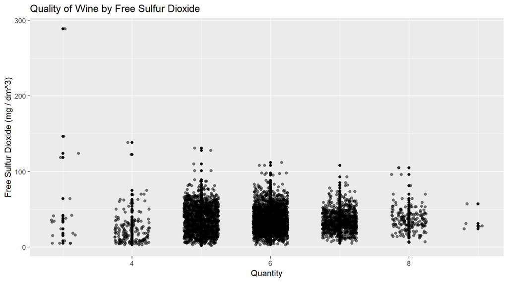

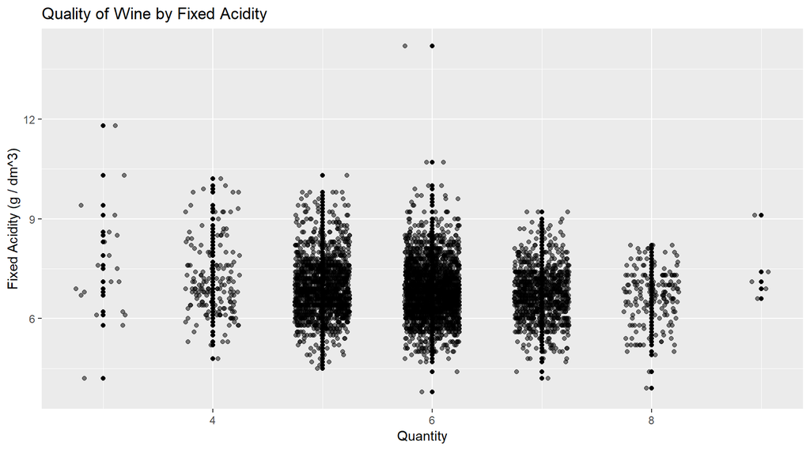

Acidity of wine gives it that fresh crisp taste according to wineskills.co.uk, but needed to know if truly a crisp taste really determined its quality?

From the plot above, we can see that as quality increased there was a gradual drop in fixed acidity. There are more observation between 5 and 7 quality score.

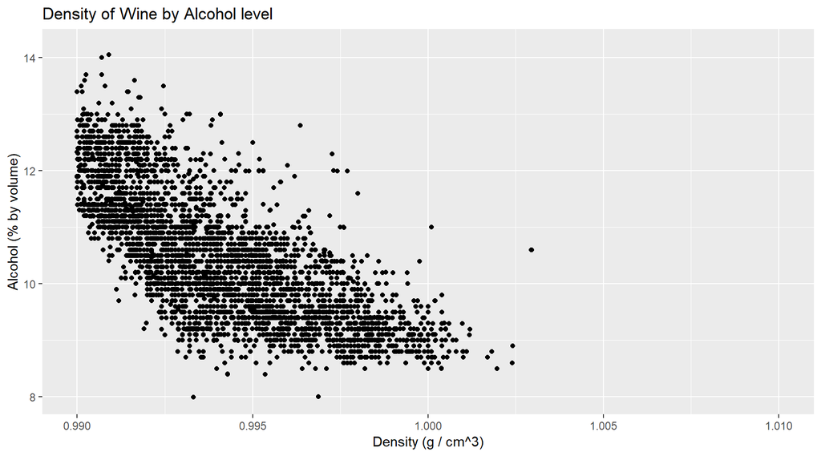

Since density and quality had an inverse relationship, alcohol on the other hand having the opposite(increasing quality, increasing alcohol level), I decided to plot both to see their relationship.

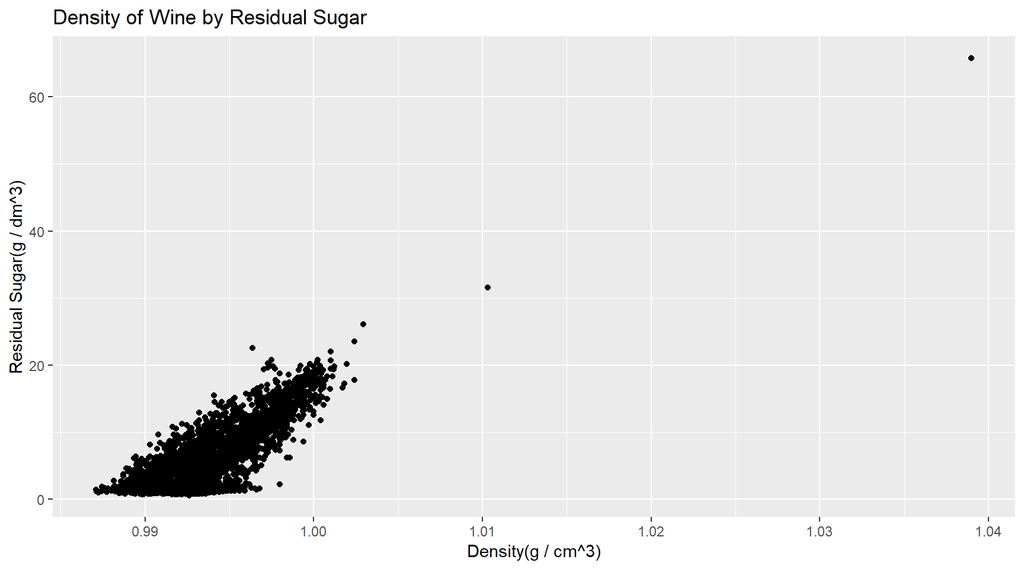

Reading about residual sugar in wine, I understood that an increase in density was a result of an increase residual sugar amongst other things. I wanted to confirm if this was true about my dataset.

It turned out that an increase in density did result in an increase residual sugar. It has one of the strongest relationships out of all the bivariate plots above.

# Bivariate Analysis

### Talk about some of the relationships you observed in this part of the investigation. How did the feature(s) of interest vary with other features in the dataset?

- Quality of wine by alcohol level; When compared with the scatter plot, there seems to be a moderate increase of quality as alcohol level increases.
- Quality of Wine by Density; There’s a decrease as quality increases which might not be so obvious.
- Quality of wine by free sulfur dioxide; There is little increment in quality as quality increases.
- Quality of wine by fixed acidity; A negative relationship is observed. Although from the plot it’s not so obvious but as fixed acidity reduces, quality increases

### Did you observe any interesting relationships between the other features (not the main feature(s) of interest)?

- Density and Alcohol level; As alcohol levels dropped, Density increased showing a negative relationship.
- Density and Residual Sugar; These two variables have an exponential relationship, as residual sugar increases, density did increase.

### What was the strongest relationship you found?

The relationship between Density and Residual Sugar.

# Multivariate Plots Section

[figure not shown]

After the bivariate plots, I was looking for interesting relationships between the variables explored in the section before this. Residual Sugar and Density had a strong exponential relatioship, what about adding alcohol and quality to the picture.

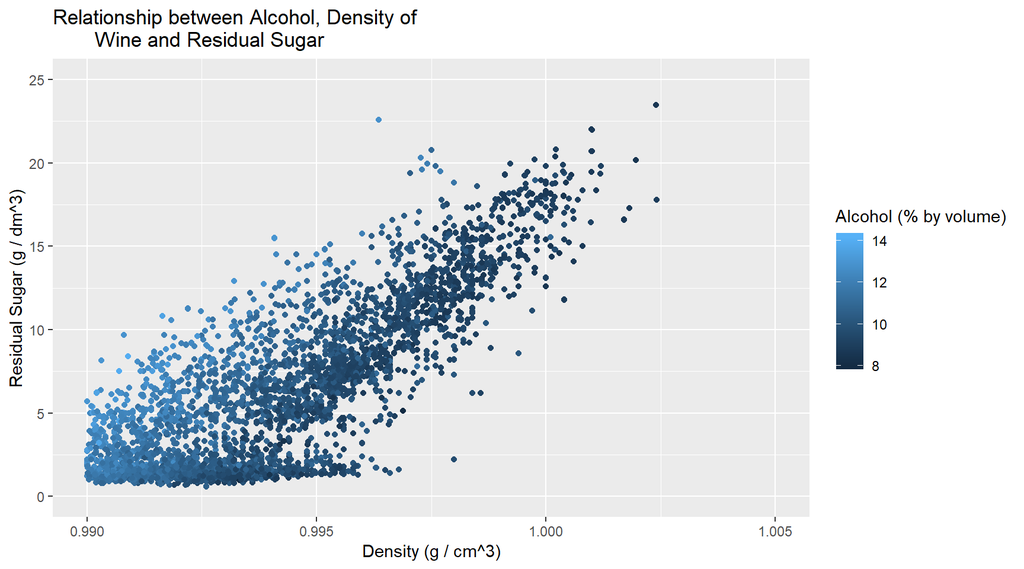

Knowing that density and residual sugar had an exponential relationship, I wanted to know it’s overall effect on alcohol was different.

It showed a decrease in % by volume as residual sugar and density increased.

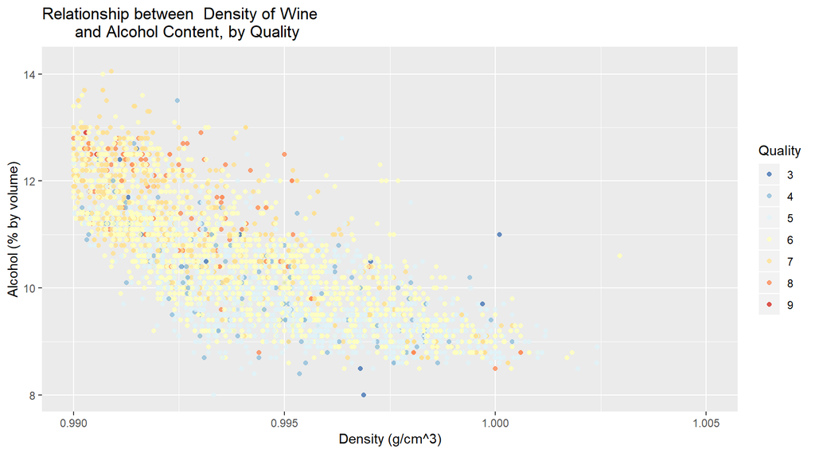

Streamlinig my exploration, I needed to confirm my ‘thoughts’ on the relationship between Alcohol Density and Quality.

Found out from the plot that an increase in density led to a decrease in alcohol level but the interesting thing is that the color palate used shows that quality also reduces with increasing density. It shows the higher quality marks at the top and then it becomes scanty below, being populated with quality marks between 6 - 3(with 5 and 6 being more pronounced).

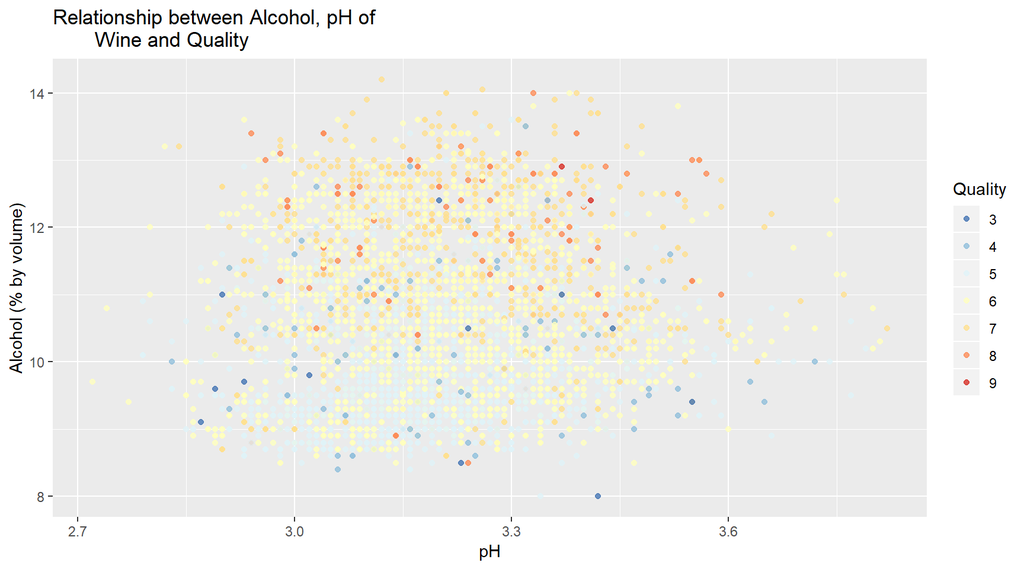

pH was one of the first things I thought would determine Quality.

It’s a bit difficult to tell from the plot as the relationship might be close to neutral.

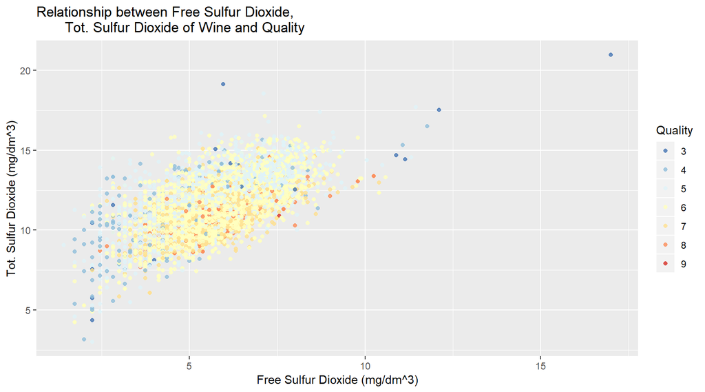

This was a final effort to see what other variable could influence quality.

Surprisingly, it’s interesting to see that for the first part of the plotted observations, quality was about 3 - 4 get close to the 5 mg/dm^3, we find out that majority of the points have quality between 5 - 6 (mostly 5 and 6) then after that area we have some outliers with 3 and 4 quality mark(score).

# Multivariate Analysis

### Talk about some of the relationships you observed in this part of the investigation. Were there features that strengthened each other in terms of looking at your feature(s) of interest?

- Relationship between Alcohol, Density and Residual Sugar; There was a steady decrease in alcohol level as both density and Residual Sugar had an exponential realtionship.
- Relationship between Quality, Density and Alcohol; This showed a decreasing realtionship between density and alcohol. Quality of wine seemed to have a decrease as the top part of the plot is populated by the key color for 8, 7, and 6 quality while the lower part had 5 - 3 populate them.

### Were there any interesting or surprising interactions between features?

- I was hoping to get a significant interaction between pH, Alcohol and Quantity but there seems to be little or no relationship.

### OPTIONAL: Did you create any models with your dataset? Discuss the strengths and limitations of your model.

# Final Plots and Summary

### Plot One

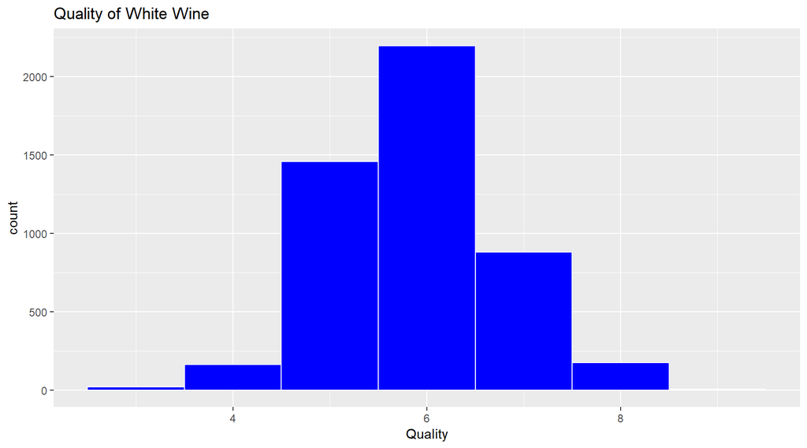

### Description One

The histogram above show the number of observations and their different quality marks. It has a normal distribution with a majority of observations having 6 as their quality score followed by 5 then 7 with the lowest number of observations having 9 (which is the highest quality score). Since I am looking at measuring Quality as a feature, I thougth it wise to know the quality of different observations.

### Plot Two

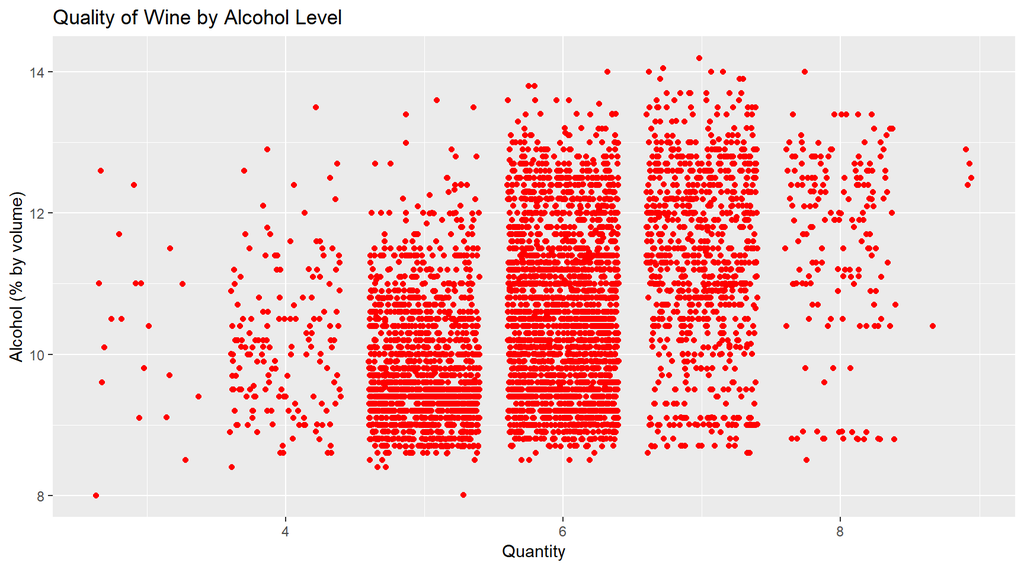

### Description Two

The scatterplot shows the relationship between alcohol and quality. With a moderate increasing relationship, increase in alcohol level leads to a very slight increase in quality. Since my aim was to investigate the chemical constituentreaponsibke for the quality of the wine, this plot was of interest to me.

### Plot Three

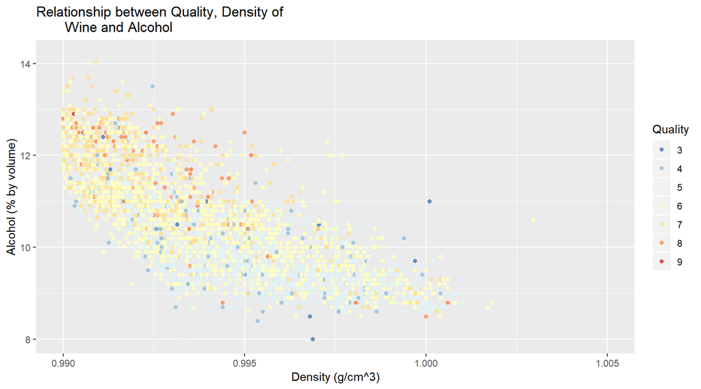

# Reflection

After reading about white wine on the internet and how they physically detected good wine, I learned that taste, color, Smell and pH level were part of what made a wine quality. After doing an analysis on this data set, it looks more like alcohol showed some signficance when compared with quality. My assumption was that it won’tbe so significant. Density and Residual sugar showed the strongest relationship which I wasn’t surprised about but when I compared Alcohol to density, I sensed that this might also be true in real life (Increase density, reduced acohol levels).

I quickly understood the importance of design principles in visuakization. There wasn’t so much difficulty in exploring the data, I just had minor issues as I used Stackoverflow, The R community and R documentation to aid me as I learned new syntax. I would try working on comparing this data with others and using R in exploring more data.